# test2

Xinyue Li

2015年11月29日

Using the abalone data:

```r
#Download abalone Dataset and get ready for exam
aburl = 'http://archive.ics.uci.edu/ml/machine-learning-databases/abalone/abalone.data' #store the dataset location into a variable aburl
abnames = c('Sex','Length','Diameter','Height','Whole_wgt','Shucked_wgt','Viscera_wgt','Shell_wgt','Rings')#create a variable abnames and put column names in it
abalone = read.table(aburl, header = F, sep = ',', col.names = abnames) #create dataset ablane and read table from aburl web dataset without header, treat ',' as separator, and using the column names in abnames
```

1. Take samples of 1%, 10%, 25%, 50%, 80%, and 100% of the data(4177). Calculate the min, max, mean and variance of the Whole_wgt column from each sample and store in a dataframe. There should be 6 columns and four rows in the dataframe (a column for each sample size and a row for each measure). Name the mean row SampleMean, the other rows appropriately, and the columns based on the % sample.

```r
#for this question, we will first create a function whole_wgt_sample to take samples from the data as we want and calculate the min, max, mean and variance of the whole cholumn of sample we get.
#Then we use a function dataframe1 to put the results we get from whole_wgt_sample with 5 kinds of sample sizes together into a dataframe, rename the row and column names and output the dataframe.
whole_wgt_sample<-function(data1,x,tolnum){ #create a functiin called whole_wgt_sample with data1, x and tolnum inputs. data1 means the data we use, x is the samplesize and tolnum is the total number of samples in data1
  s<-data1[sample(length(data1), round(tolnum*x), replace = FALSE)] #create a variable s and use it to store selected sample from data1 with samplesize we want without replacement
  sn<-c(min(s),max(s),mean(s),var(s)) #create a variable sn to store the min, max, mean and variance of s
  sn #output sn
} #finish function
dataframe1<-function(data1){ #create a function dataframe1 with input data1 which means the data we use
  samplesize<-c(.01,.1,.25,.5,.8,1) #create variable samplesize and put the percentage of samplesize we want in it
  q1<-data.frame(whole_wgt_sample(data1,samplesize[1],length(data1)),whole_wgt_sample(data1,samplesize[2],length(data1)),whole_wgt_sample(data1,samplesize[3],length(data1)),whole_wgt_sample(data1,samplesize[4],length(data1)),whole_wgt_sample(data1,samplesize[5],length(data1)),whole_wgt_sample(data1,samplesize[6],length(data1))) #create dataframe q1 and put the output of whole_wgt_sample with 5 kinds of sample sizes together into it
  rownames(q1)=c('SampleMin', 'SampleMax', 'SampleMean', 'SampleVar') #name q1 rows as required
  colnames(q1)<-c('1%sample','10%sample','25%sample','50%sample','80%sample','100%sample') #name q1 columns as required
  q1 #output dataframe q1
} #finish function
dataframe1(abalone$Whole_wgt) #run function dataframe1 with abalone$Whole_wgt data
```

```
##             1%sample 10%sample 25%sample 50%sample 80%sample 100%sample
## SampleMin  0.0815000 0.0240000 0.0020000 0.0020000 0.0020000  0.0020000
## SampleMax  1.4105000 2.7795000 2.6570000 2.8255000 2.8255000  2.8255000
## SampleMean 0.7866190 0.8497548 0.8224114 0.8327342 0.8261828  0.8287422
## SampleVar  0.1206418 0.2592394 0.2464895 0.2425157 0.2399637  0.2404814
```

2. Create a grid of histograms that contains all sample sizes.

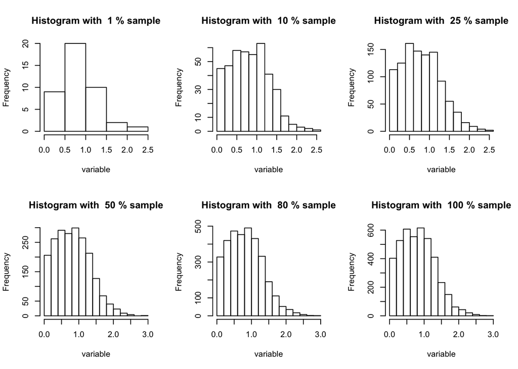

```r
#Because this question is very similar to the question 4, we will create a small function that can be used in both questions first.
#This function will help to draw a well-organized histogram for the data we use. Then we create function gridhist1 to draw a grid of histograms for each sample size by using par() and a for loop function
histg<-function(dataset,y){ #create a function histg with input dataset and y, dataset is the data we use and y is the samplesize
  hist(dataset, #using hist() to draw hisgtogram for dataset
      main=paste('Histogram with ',round(y*100),'% sample'), #create the title for histogram and mention input samplesize
      xlab='variable') #simple name the xlab variable, because we will use it to other datas
}
gridhist1<-function(data1){ #create a function gridhist1 with input data1
  samplesize<-c(.01,.1,.25,.5,.8,1) ##create variable samplesize and put the percentage of samplesize we want in it
  samplenum<-round(length(data1)*samplesize) #create variable samplenum it is the number of samples we need to take for each samplesize
  par(mfrow=c(2,3)) #using par() to arrange the histogram in 2 rows and 3 columns
  for (i in 1:(length(samplenum))){ #using for loop to go through from the first sample number to the last
    s2<-c() #create a variable s2 and make it empty, it is the we will us it as a temporary variable to draw histogram.
    s2<-data1[sample(length(data1),samplenum[i],replace = FALSE)] #let s2 be the samples selected from data1 with certain samplesize and without replacement
    histg(s2,samplesize[i]) #using function histg() to draw individual histogram for the certain samplesize
  }
}#finish function
gridhist1(abalone$Whole_wgt) #run function gridhist1() with abalone$Whole_wgt
```

3. Implement a loop that takes 1,000 samples at each of the sample sizes in 1 above (except the 100% sample!). Calculate a mean at each iteration and store the results in a dataframe. There should be four columns and 1,000 rows. Name the columns but NOT the rows.

```r
#for this question, we will create a function to take 1000 samples for each sample size, store in dataframe, and calculate the means for every 1000 samples and store in a variable
dataframe2<-function(data1){ #create a function dataframe2() with input data1
  samplesize<-c(.01,.1,.25,.5,.8,1) #create variable samplesize and put the percentage of samplesize we want in it
  a<-data.frame(c1=c(NA),c2=c(NA),c3=c(NA),c4=c(NA),c5=c(NA))#create an empty dataframe a with 5 columns
  mean3<-c()#create variable mean3, make it empty, we will put mean for 1000 samples in it
  for (i in 1:(length(samplesize)-1)){ #using for loop to go through all samplesize except 100% sample
    s<-c() #create variable s, make it empty
    s<-data1[sample(length(data1), round(length(data1)*samplesize[i]), replace = FALSE)]#let s be the samples selected from data1 with certain samplesize and without replacement
    for (j in 1:1000){ #using for loop to repeat the following code 1000 times
      a[j,i]<-s[sample(length(s),1,replace=FALSE)] #select 1 sample from s and put it into dataframe a
    }#end the second for loop
    mean3[i]<-mean(a[,i]) #put mean for each iteration into mean3
  }#end the first for loop
  colnames(a)<-c('1%sample','10%sample','25%sample','50%sample','80%sample') #name the columns for a as required
  a #output a
} #finish function
dataframe2(abalone$Whole_wgt) #run dataframe2() with abalone$Whole_wgt
```

```
##      1%sample 10%sample 25%sample 50%sample 80%sample
## 1      0.5905    1.4355    0.9755    1.7775    0.6140
## 2      0.4445    0.8730    1.7400    1.0680    0.6570
## 3      1.9740    1.5165    0.9670    2.1410    0.6640
## 4      1.0345    0.0545    1.0045    0.1830    2.1425
## 5      1.6060    0.6990    1.4010    0.1060    0.4195
## 6      0.7240    0.8970    1.1370    1.7570    0.9015
## 7      1.0525    1.3695    1.3765    0.5805    0.3030
## 8      0.1400    1.5980    1.6200    0.8645    1.5640
## 9      1.0920    0.6730    0.9700    1.2850    0.9800
## 10     1.5845    0.3595    1.3850    0.3275    0.4760
## 11     1.6060    1.3400    0.8085    0.0950    0.8340
## 12     1.1085    0.5780    0.7635    1.2525    0.1870
## 13     1.1085    1.6525    0.4790    1.2865    1.2915
## 14     0.5510    1.7930    0.1610    0.7045    0.1710
```

[output cut: 986 more lines]

4. Create another grid of histograms that contains the four columns just created and include the 100% sample from 1. (HINT: You should create a function to solve 2 and reuse here).

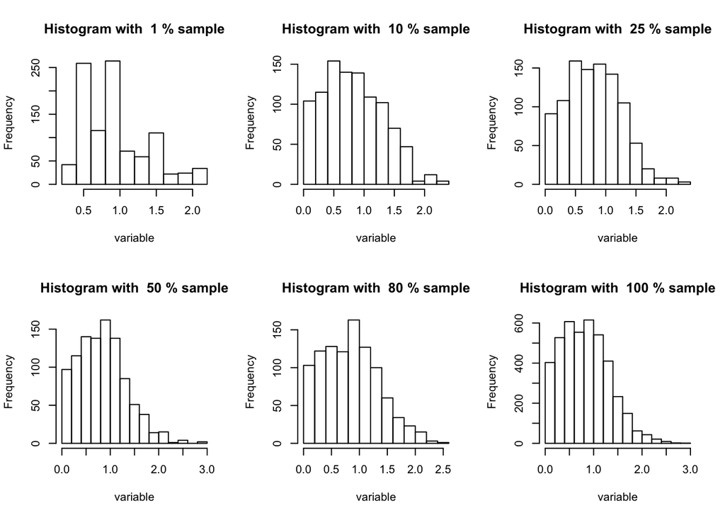

```r
#In this question, we will create a function gridhist2(), using the function histg() to create the grid of histograms for all columns in a and 100% sample
gridhist2<-function(data1){ #create a function gridhist2() with input data1
  size4<-c(0.01,0.1,0.25,0.5,0.8) #create a variable size4 with samplesize in we used for a
  par(mfrow=c(2,3)) #using par() to arrange the histogram in 2 rows and 3 columns
  for (i in 1:5){ #using for loop to go through all values in size4
    histg(dataframe2(data1)[,i],size4[i]) #using histg() to plot histograms for all columns in a
  } #end for loop
  histg(data1,1) #using histg() to plot histogram for 100% sample
} #finish function
gridhist2(abalone$Whole_wgt) #run gridhist2() with abalone$Whole_wgt
```

5. Calculate the min, max, mean and variance of each column from 3 and of the total dataset (the 100% sample). Append to the dataframe created in 1. Name the mean row ResampleMean and the others appropriately.

```r
#we will create a function dataframe3 to calculate min, max, mean and variance of each column in dataframe a and the 100% sample, and put them into a dataframe
dataframe3<-function(data1){ #create function dataframe3 with input data1
  rea<-data.frame(c1=c(NA),c2=c(NA),c3=c(NA),c4=c(NA),c5=c(NA)) #create an empty dataframe rea with 5 columns
  for (i in 1:5){ #using for loop to go through all columns in rea
    rea[1,i]<-min(dataframe2(data1)[,i]) #calculate min of rea columns
    rea[2,i]<-max(dataframe2(data1)[,i]) #calculate max of rea columns
    rea[3,i]<-mean(dataframe2(data1)[,i]) #calculate mean of rea columns
    rea[4,i]<-var(dataframe2(data1)[,i]) #calculate var of rea columns
  }#end for loop
  q5<-data.frame(rea,whole_wgt_sample(data1,1,length(data1))) #create dataframe q5 and put rea and 100% sample together in q5
  rownames(q5)=c('ResampleMin', 'ResampleMax', 'ResampleMean', 'ResampleVar')#name q5 rows as required
  colnames(q5)<-c('1%sample','10%sample','25%sample','50%sample','80%sample','100%sample') #name q5 columns as required
  q5 #output dataframe q5
} #finish function
dataframe3(abalone$Whole_wgt)#run dataframe3() with abalone$Whole_wgt
```

```
##              1%sample 10%sample 25%sample 50%sample 80%sample 100%sample
## ResampleMin  0.028000  0.014500 0.0020000 0.0080000 0.0145000  0.0020000
## ResampleMax  2.238500  2.548000 2.8255000 2.8255000 2.6570000  2.8255000
## ResampleMean 0.754669  0.785548 0.8051360 0.8192700 0.8279850  0.8287422
## ResampleVar  0.177143  0.213293 0.2554273 0.2421949 0.2751379  0.2404814
```

6. Create a single histogram of the 100% data and overlay and label lines that represent the 1%, 10%, 25%, 50%, and 80% SampleMean.

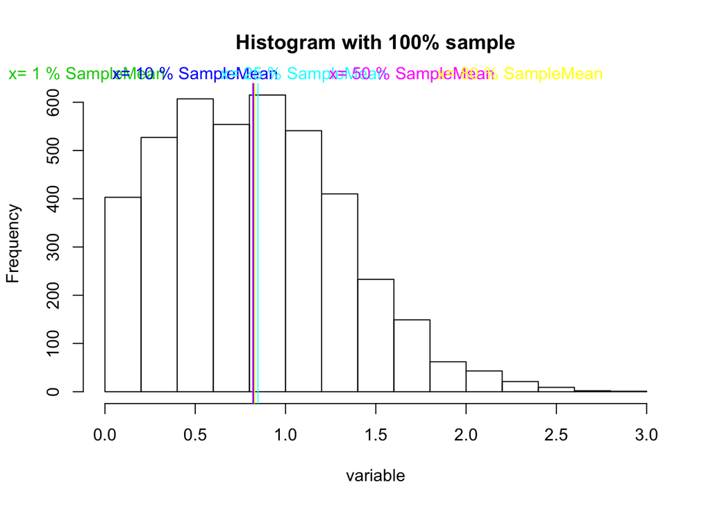

```r
#we will create a function to create a single histogram of 100% data and overlay and label lines that represent the 1%, 10%, 25%, 50%, and 80% SampleMean
histogram1<-function(data1){ #create a function histogram1 with input data1
  par(mfrow=c(1,1)) #using par() to arrange the one single histogram in plots area
  nums<-c(1,10,25,50,80) #create a variable nums and just use it in creatning the xtext for each lines represent the 1%, 10%, 25%, 50%, and 80% SampleMean in histogram
  hist(data1,main=paste('Histogram with 100% sample'),xlab='variable')#using hist() to create histogram with data1, name the title 'Histogram with 100% sample' and name x label variable
  for (i in 1:(length(dataframe1(data1)[3,])-1)){#using for loop to go through all samplemean in q1 except 100% samplemean
    abline(v=dataframe1(data1)[3,i],col=i+2)#draw vertical line for each samplemean with different color
    mtext(paste('x=',nums[i],'% SampleMean'),at=-0.7+i*0.6,col=i+2)#using mtext to write text x=i% SampleMean for each vertical line with certain color in histogram, and using at to put them seperate
  } #end for loop
} #finish function
histogram1(abalone$Whole_wgt)#run histogram1() with abalone$Whole_wgt
```

7. Create a second histogram of the 100% data and overlay and label vertical lines that represent the 1%, 10%, 25%, 50%, and 80% ResampleMean.

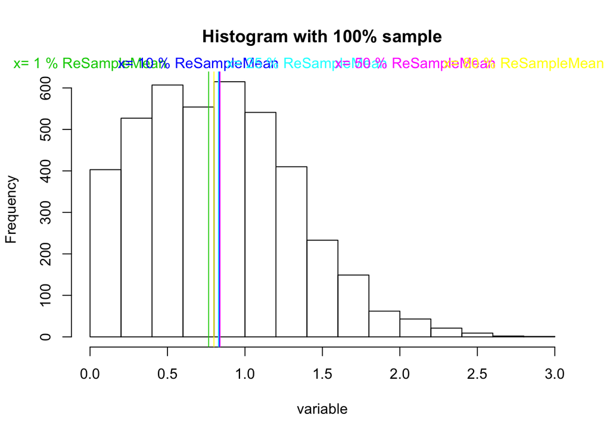

```r
#we will create a function to create a single histogram of 100% data and overlay and label lines that represent the 1%, 10%, 25%, 50%, and 80% ResampleMean
histogram2<-function(data1){ #create function histogram2 with input data1
  par(mfrow=c(1,1)) #using par() to arrange the one single histogram in plots area
  nums<-c(1,10,25,50,80)#create a variable nums and just use it in creatning the xtext for each lines represent the 1%, 10%, 25%, 50%, and 80% resampleMean in histogram
  hist(data1,main=paste('Histogram with 100% sample'),xlab='variable')#using hist() to create histogram with data1, name the title 'Histogram with 100% sample' and name x label variable
  for (i in 1:(length(dataframe3(data1)[3,])-1)){#using for loop to go through all resamplemean in q5 except 100% resamplemean
    abline(v=dataframe3(data1)[3,i],col=i+2)#draw vertical line for each resamplemean with different color
    mtext(paste('x=',nums[i],'% ReSampleMean'),at=-0.7+i*0.7,col=i+2)#using mtext to write text x=i% ReampleMean for each vertical line with certain color in histogram, and using at to put them seperate
  }#end for loop
}#finish function
histogram2(abalone$Whole_wgt)#run histogram2() with abalone$Whole_wgt
```

8. Now execute your code on diamonds$carat and faithful$eruptions.

```r
require(ggplot2)
#execute functions on diamonds$carat, all works well
dataframe1(diamonds$carat)
```

```
##             1%sample 10%sample 25%sample 50%sample 80%sample 100%sample
## SampleMin  0.2000000 0.2000000 0.2000000 0.2000000 0.2000000  0.2000000
## SampleMax  2.4800000 3.2200000 5.0100000 4.0100000 4.5000000  5.0100000
## SampleMean 0.7627087 0.8021913 0.7983129 0.7985799 0.7974488  0.7979397
## SampleVar  0.2033458 0.2191735 0.2217156 0.2250398 0.2235350  0.2246867
```

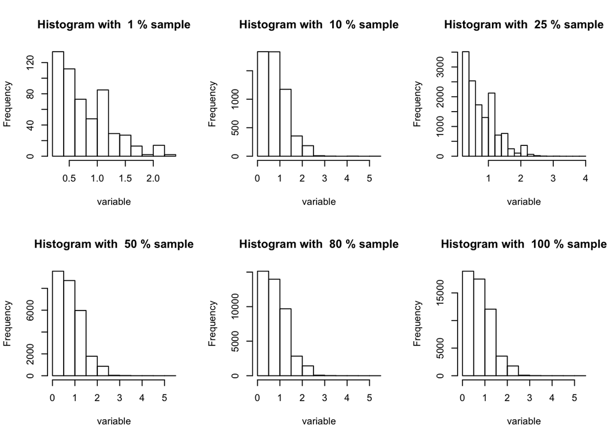

```r
gridhist1(diamonds$carat)
```

```r
dataframe2(diamonds$carat)
```

```
##      1%sample 10%sample 25%sample 50%sample 80%sample
## 1        1.30      0.30      0.92      0.33      0.51
## 2        1.26      0.72      0.36      1.27      1.52
## 3        0.70      0.30      0.30      1.70      0.50
## 4        0.39      0.26      1.20      0.28      2.01
## 5        1.00      0.51      0.60      0.30      0.74
## 6        0.52      0.41      1.24      0.51      0.74
## 7        0.32      0.30      0.35      0.31      0.90
## 8        0.40      0.31      1.23      0.30      1.20
## 9        0.53      2.00      2.03      0.50      1.50
## 10       2.03      2.01      0.31      2.32      1.13
## 11       0.30      0.70      2.00      0.71      0.78
## 12       1.51      0.33      0.43      0.38      0.71
## 13       0.31      0.32      1.24      1.40      0.36
## 14       1.11      0.28      1.10      1.28      1.01
```

[output cut: 986 more lines]

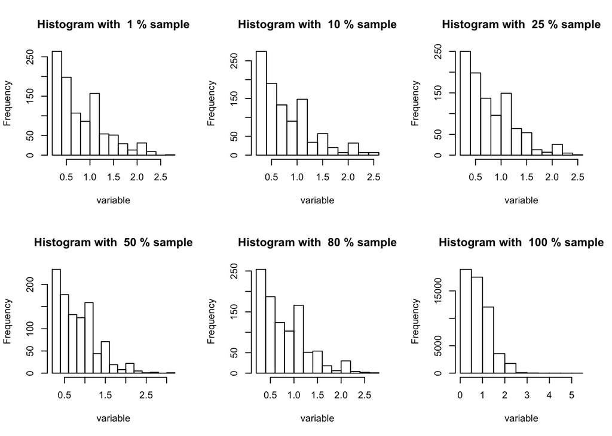

```r
gridhist2(diamonds$carat)
```

```r
dataframe3(diamonds$carat)
```

```
##              1%sample 10%sample 25%sample 50%sample 80%sample 100%sample
## ResampleMin  0.230000 0.2000000 0.2300000 0.2100000 0.2100000  0.2000000
## ResampleMax  3.000000 2.5100000 3.1100000 2.3800000 2.6600000  5.0100000
## ResampleMean 0.844750 0.8170400 0.7509600 0.8016600 0.8034200  0.7979397
## ResampleVar  0.205996 0.2249729 0.2049407 0.2228854 0.2254953  0.2246867
```

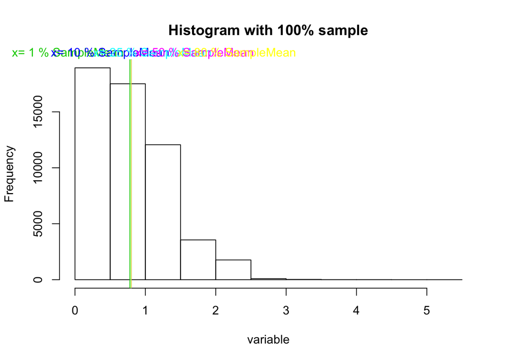

```r
histogram1(diamonds$carat)
```

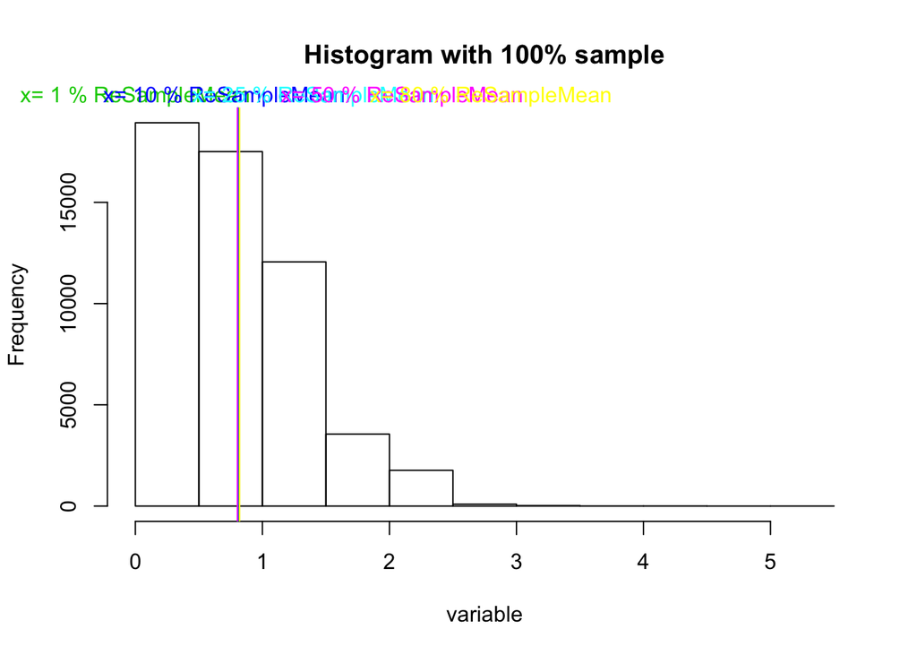

```r
histogram2(diamonds$carat)
```

```r
#execute functions on faithful$eruptions, all works well
dataframe1(faithful$eruptions)
```

```
##              1%sample 10%sample 25%sample 50%sample 80%sample 100%sample
## SampleMin  1.98300000  1.750000  1.750000  1.667000  1.600000   1.600000
## SampleMax  2.28300000  5.033000  5.067000  5.000000  5.100000   5.100000
## SampleMean 2.15533333  3.259852  3.479912  3.468493  3.507844   3.487783
## SampleVar  0.02399633  1.317002  1.397539  1.303290  1.289575   1.302728
```

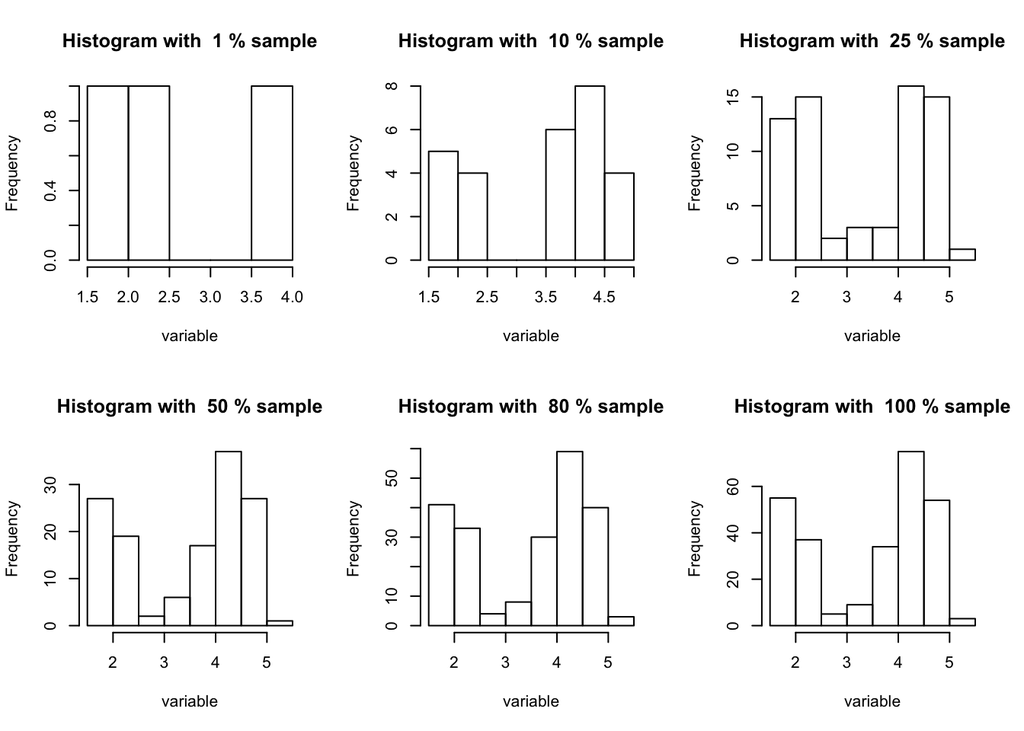

```r
gridhist1(faithful$eruptions)
```

```r
dataframe2(faithful$eruptions)
```

```
##      1%sample 10%sample 25%sample 50%sample 80%sample
## 1       4.667     3.767     3.917     4.000     4.083
## 2       4.133     3.767     4.700     2.100     4.900
## 3       4.583     4.633     4.150     4.817     2.617
## 4       4.133     4.417     4.183     3.767     4.567
## 5       4.583     4.567     4.533     4.150     2.483
## 6       4.583     3.850     4.800     1.867     3.850
## 7       4.583     1.967     2.883     1.950     1.967
## 8       4.133     1.750     1.917     2.250     3.833
## 9       4.667     2.283     3.917     1.833     4.500
## 10      4.667     4.617     1.917     4.450     3.333
## 11      4.583     1.883     4.817     1.750     2.267
## 12      4.667     1.883     4.000     2.017     4.000
## 13      4.583     1.967     4.100     4.333     1.850
## 14      4.667     4.417     4.817     1.833     4.250
```

[output cut: 986 more lines]

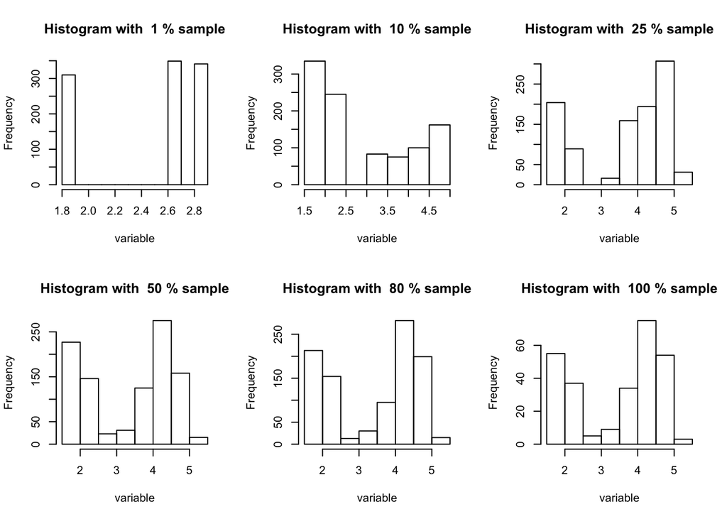

```r
gridhist2(faithful$eruptions)
```

```r
dataframe3(faithful$eruptions)
```

```
##               1%sample 10%sample 25%sample 50%sample 80%sample 100%sample
## ResampleMin  1.8670000  1.750000  1.750000  1.700000  1.600000   1.600000
## ResampleMax  5.0670000  5.100000  4.933000  5.100000  5.100000   5.100000
## ResampleMean 3.5920480  3.593693  3.407673  3.424201  3.474882   3.487783
## ResampleVar  0.6324796  1.119628  1.183896  1.292259  1.254149   1.302728
```

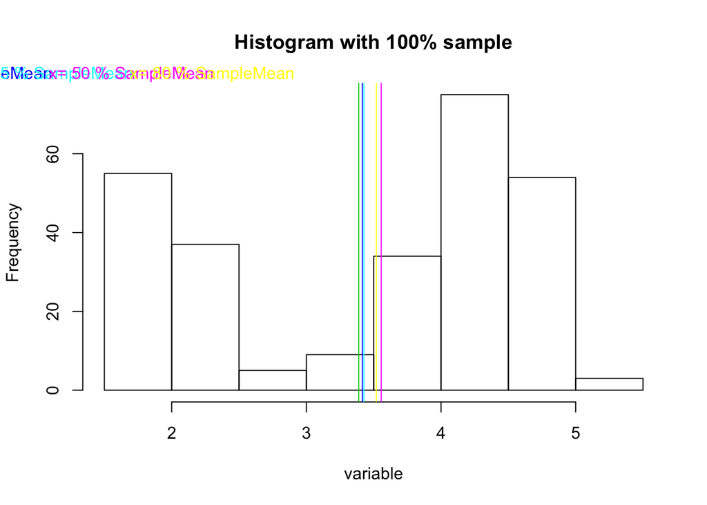

```r
histogram1(faithful$eruptions)
```

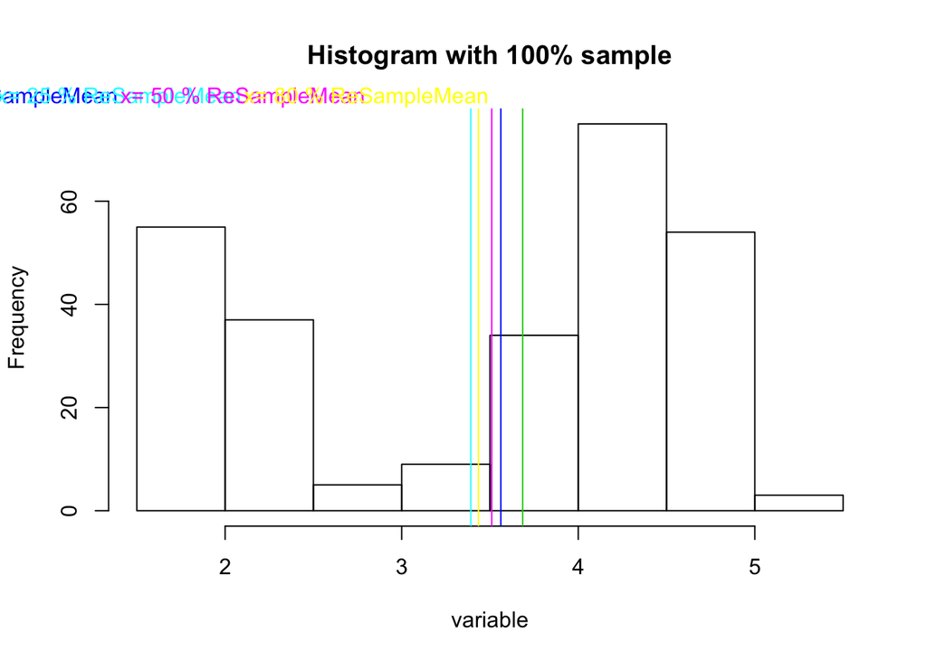

```r
histogram2(faithful$eruptions)
```

9. Provide a brief explanation of what you observe in the measures and histograms as it relates to sample size and resampling.

```r
#By comparing SampleMean and ReampleMean, gridhist1 and histogram1: When sample size become larger, the measures and histograms will get more stable and closer to the measures and histograms of full dataset
#By comparing SampleVar and ReampleVar, gridhist1 and histogram2:When resampling the data for 1000 times, the measures and histograms will become more stable but won't be closer to the full dataset
#When the sample size become larger and resampling the data for 1000 times, the measures and histograms will become more stable and closer to the measures and histogram of full dataset.
```